# polesvscentrioles

Meelad Amouzgar

```r
library(ggplot2)
```

This is a mini-project where I analyze a small subset of biological data that I collected (full dataset is not used to for publication privacy as this data is not published yet)

```r
df <- read.csv("031519_polesVcentrioles.csv")
```

```r
library(corrplot)
cor.test(df$centrioles, df$poles)
```

```
##
##  Pearson's product-moment correlation
##
## data:  df$centrioles and df$poles
## t = 23.033, df = 480, p-value < 2.2e-16
## alternative hypothesis: true correlation is not equal to 0
## 95 percent confidence interval:
##  0.6792091 0.7644146
## sample estimates:
##       cor
## 0.7245689
```

```r
# df$supernumerary <- ifelse(df$poles ==2 & df$centrioles == 4, NA, df$centrioles)
# df$multipolar <- ifelse(df$poles > 2, df$poles,NA)
```

Understanding relationships between spindle architecture and chromosome # in cancer at the single cell level.

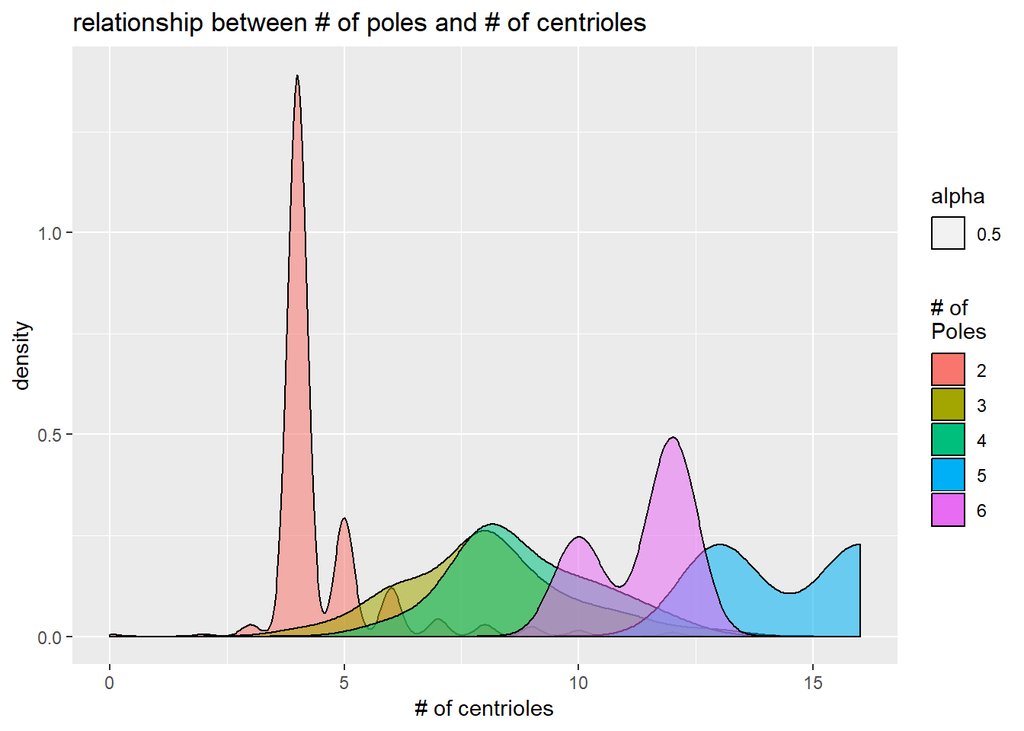

```r
g <- ggplot(data=df)
g + geom_density(aes(x=centrioles, fill=factor(poles), alpha=.5)) +
  ggtitle("relationship between # of poles and # of centrioles") +
  xlab("# of centrioles") +
  scale_fill_discrete(name="# of\nPoles")
```

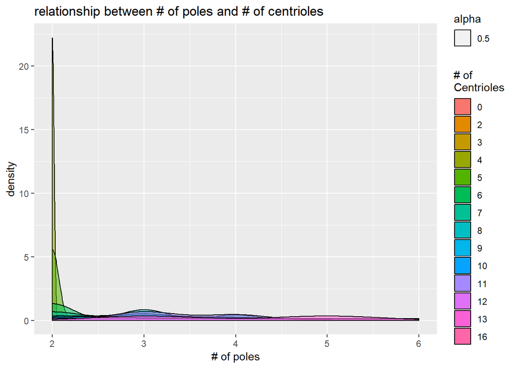

```r
g + geom_density(aes(x=poles, fill=factor(centrioles), alpha=.5)) +
  ggtitle("relationship between # of poles and # of centrioles") +
  xlab("# of poles") +
  scale_fill_discrete(name="# of\nCentrioles")
```

```r
  # theme(plot.title = element_text(size = 15))
```

There appears to be a correlation between # of spindle poles and centrosomes, where an increased # of centrosomes is correlated with spindle multipolarity.

To better focus in on how spindle multipolarity scales with # of centrioles, I will remove bipolar spindles (where # of poles = 2)

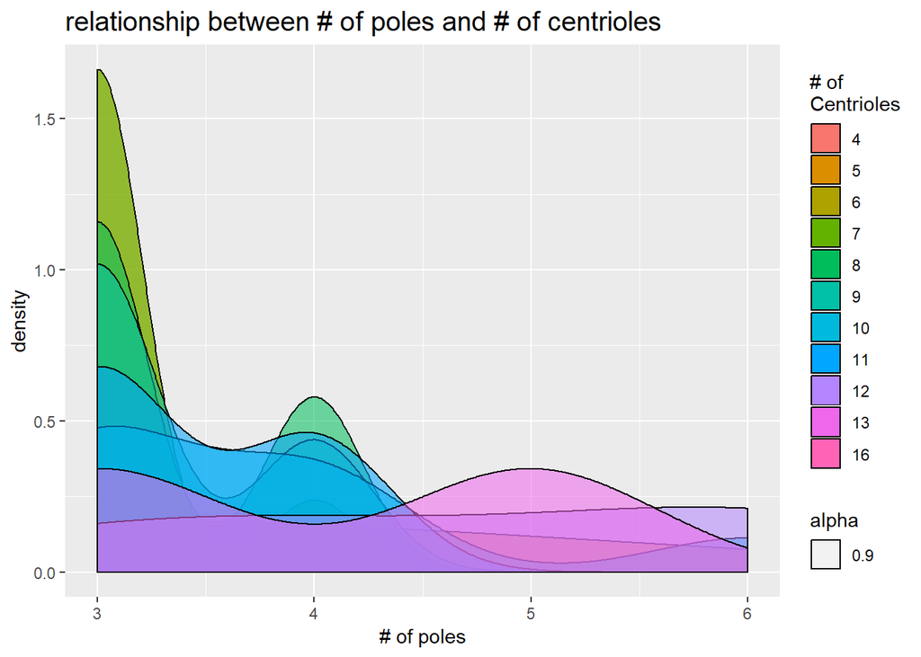

```r
df2 <- subset(df, select = -c(kinetochores)) # remove kinetochores

df3 <- df2 # no bipolar spindles
supernumerary_ind <- which(df3$poles >2)
is.na(df3$centrioles) <- -supernumerary_ind

g <- ggplot(data=na.omit(subset(df3, select = c(poles, centrioles))))
g + geom_density(aes(x=poles, fill=factor(centrioles), alpha=.9)) +
  ggtitle("relationship between # of poles and # of centrioles") +
  xlab("# of poles") +
  scale_fill_discrete(name="# of\nCentrioles")+
  theme(plot.title = element_text(size = 15))
```

There appears to be a poisson-like distribution, where the median total # of centrioles increases as centrosomes increase and the distribuion gets wider. A larger sample size would highlight this point better.

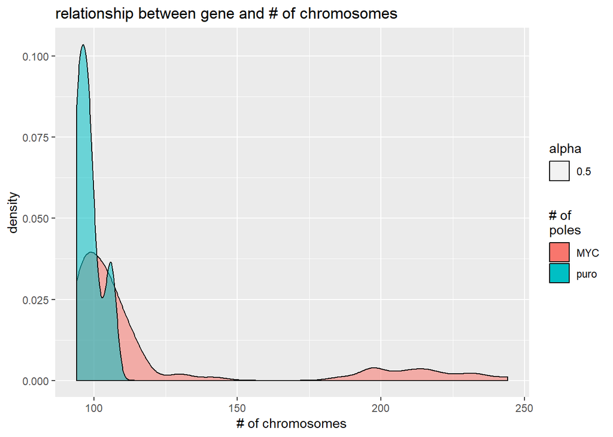

```r
df_kinetochores <- subset(df, select = c(gene,poles,centrioles, kinetochores))
# df_kinetochores <- na.omit(df_kinetochores)

kinetochores <- ggplot(data=df_kinetochores)
kinetochores + geom_density(aes(x=kinetochores, fill=factor(gene), alpha=.5)) +
  ggtitle("relationship between gene and # of chromosomes") +
  xlab("# of chromosomes") +
  scale_fill_discrete(name="# of\npoles")
```

Understanding how chromosome # scales with altered mitotic spindle architecture.

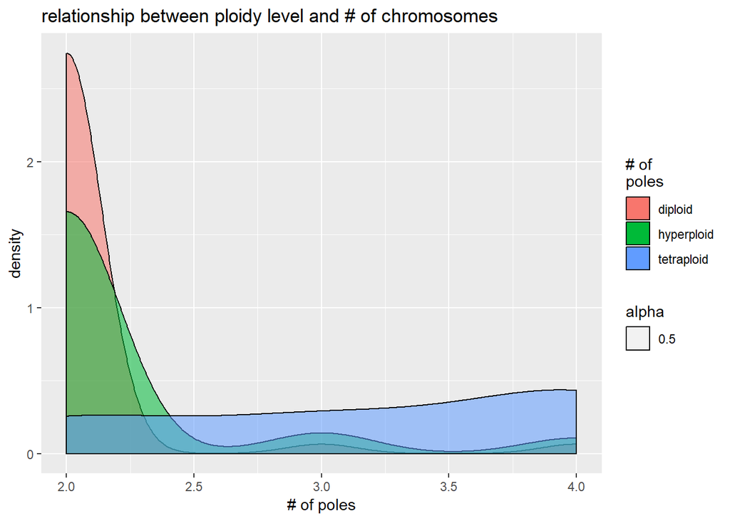

```r
df$ploidy <- ifelse(df$kinetochores > 90 & df$kinetochores < 100, "diploid", NA)
df$ploidy <- ifelse(df$kinetochores >=  100 & df$kinetochores < 172, "hyperploid", df$ploidy)
df$ploidy <- ifelse(df$kinetochores >= 172, "tetraploid", df$ploidy)

# diploid <- which(df$kinetochores > 90 & df$kinetochores < 100)
# hyperploid <- which(df$kinetochores >=  100 & df$kinetochores < 172)
# tetraploid <- which(df$kinetochores >= 172)

ploidylevels <- c("diploid","hyperploid", "tetraploid")
df$ploidy <- factor(df$ploidy, labels =ploidylevels)

g <- ggplot(data=na.omit(subset(df, select = c(poles,centrioles, gene, kinetochores, ploidy))))
g + geom_density(aes(x=poles, fill=factor(ploidy), alpha=.5)) +
  ggtitle("relationship between ploidy level and # of chromosomes") +
  xlab("# of poles") +
  scale_fill_discrete(name="# of\npoles")
```

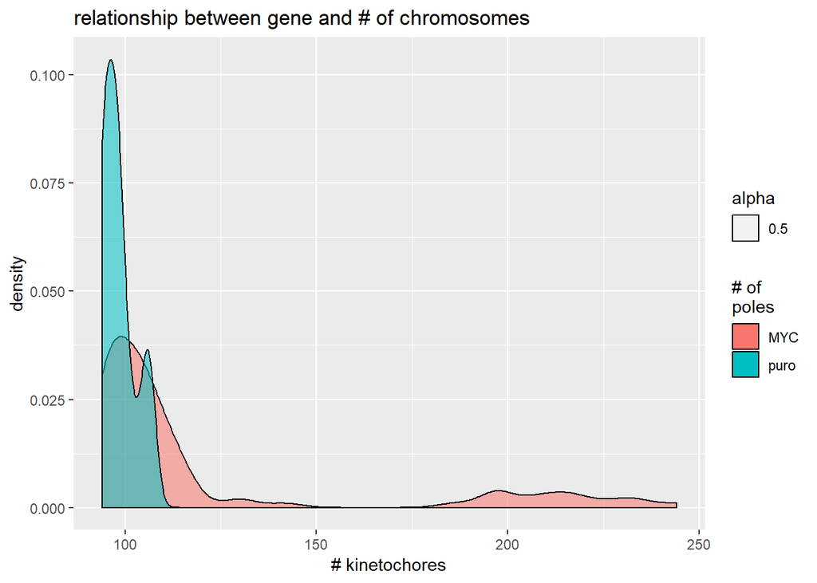

```r
g + geom_density(aes(x=kinetochores, fill=factor(gene), alpha=.5)) +
  ggtitle("relationship between gene and # of chromosomes") +
  xlab("# kinetochores") +
  scale_fill_discrete(name="# of\npoles")
```

```r
# ggplot(df, aes(poles,..count..)) + geom_bar(aes(fill = factor(ploidy)), position = "dodge")
```

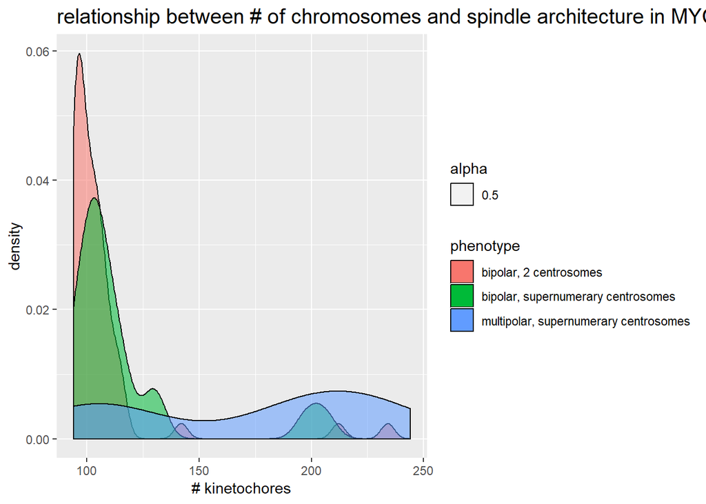

```r
df_myc <- df[df$gene=="MYC",]
df_myc$polephenotype <- ifelse(df_myc$poles ==2, "bipolar", NA)
df_myc$polephenotype <- ifelse(df_myc$poles >2, "multipolar", df_myc$polephenotype)
df_myc$polephenotype <- factor(df_myc$polephenotype, labels = c("bipolar","multipolar"))


df_myc$centriolephenotype <- ifelse(df_myc$centrioles == 4, "normal centrosomes", NA)
df_myc$centriolephenotype <- ifelse(df_myc$centrioles > 4, "supernumerary centrosomes", df_myc$centriolephenotype)
df_myc$centriolephenotype <- factor(df_myc$centriolephenotype, labels = c("normal centrosomes","supernumerary centrosomes"))

df_myc$centriole_pole_phenotype <- ifelse(df_myc$poles ==2 & df_myc$centrioles == 4, "bipolar, 2 centrosomes", NA)
df_myc$centriole_pole_phenotype <- ifelse(df_myc$poles ==2 & df_myc$centrioles > 4, "bipolar, supernumerary centrosomes", df_myc$centriole_pole_phenotype)
df_myc$centriole_pole_phenotype <- ifelse(df_myc$poles > 2 & df_myc$centrioles == 4, "multipolar, 2 centrosomes", df_myc$centriole_pole_phenotype)
df_myc$centriole_pole_phenotype <- ifelse(df_myc$poles > 2 & df_myc$centrioles > 4, "multipolar, supernumerary centrosomes", df_myc$centriole_pole_phenotype)
df_myc$centriole_pole_phenotype <- factor(df_myc$centriole_pole_phenotype, labels = c("bipolar, 2 centrosomes","bipolar, supernumerary centrosomes", "multipolar, supernumerary centrosomes" ))

q <- ggplot(data=na.omit(subset(df_myc, select = c(kinetochores, centriole_pole_phenotype))))
q + geom_density(aes(x=kinetochores, fill=factor(centriole_pole_phenotype), alpha=.5)) +
  ggtitle("relationship between # of chromosomes and spindle architecture in MYC") +
  xlab("# kinetochores") +
  scale_fill_discrete(name="phenotype") +
  theme(plot.title = element_text(size = 15))
```

We can conclude that the majority of tetraploid cells (# of kinetochores ~ >184 ) are multipolar with supernumerary centrosomes (blue), suggesting that tetraploid cells might be unable to cluster their multipolar structures into bipolar structures.